# git pull upstream master

# Answer questions from the previous session

# Creating new types

## We need more evolved contents !

## We can do python dictionary

```
planet = {
  'mass': 2.3,
  'name': mars
}
```

## Is it enough ?

## Clearly not

# Object oriented programming

- Programs are collections of individual units: the objects
- Objects have distinct types and (hence) purposes
- Functionalities of disctinct types have limited (or no) implementation dependencies
- An object gathers data (**state**) and functions (**behavior**)

[figure not shown]

[wikipedia: Object oriented (OO) programming](http://en.wikipedia.org/wiki/Object-oriented_programming)

[wikipedia: OO Fundamental concepts](http://en.wikipedia.org/wiki/Object-oriented_programming#Fundamental_features_and_concepts)

## [Classes](https://en.wikipedia.org/wiki/Class_%28computer_programming%29) and [Objects](https://en.wikipedia.org/wiki/Object_%28computer_science%29)

- A **Class** is a type definition, constructed as the blue print used to create objects
- A **Class** defines
  - [Members](https://en.wikipedia.org/wiki/Member_variable) : variables describing object states. Also called data members, characteristics, attributes, or properties.
  - [Methods](https://en.wikipedia.org/wiki/Method_%28computer_programming%29) : the actions associated with a particular object.
  - **Constructors** : particular methods setting the initial state
  - **Destructors** : particular methods destroying the object and freeing memory
- An **Object** is an [instance](https://en.wikipedia.org/wiki/Instance_%28computer_science%29) (allocated in memory) constructed from a **Class** description

## Cat example

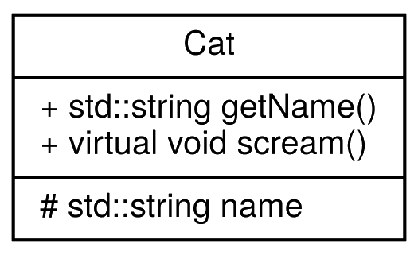

```
class Cat:
   # the constructor
   def __init__ (self, name):
      # the member name
      self.name = name

   #A given method
   def scream(self):
      print('MIAOU')

   # one accessor
   def getName(self):
      return self.name
```

**self** stands for the **current object** or **instance**

## Object instance

```
# instanciates(creates)
# a Cat
kitty = Cat('kitty')

print(kitty)
print(type(kitty))

# call of method
kitty.scream()


# force deletion
del kitty
```

[output not shown]

## *Python* constraints and features

- Methods have unique names
- named parameters are accepted

```
class Cat:
   def scream(self, scream='MIAOU'):
     print(scream)
```

- Constructor with arguments (if construction needs arguments)

```
class Cat:
   def __init__(self, name='kitty'):
    self.name = name
```

- **destructor** have no other argument than **self**

```
class Cat:
   def __del__(self):
    print('I am dying')
```

## [Inheritance](http://en.wikipedia.org/wiki/Inheritance_%28object-oriented_programming%29)

- When a Class is based on another Class
- Re-use/Factor implementation/code

[figure not shown]

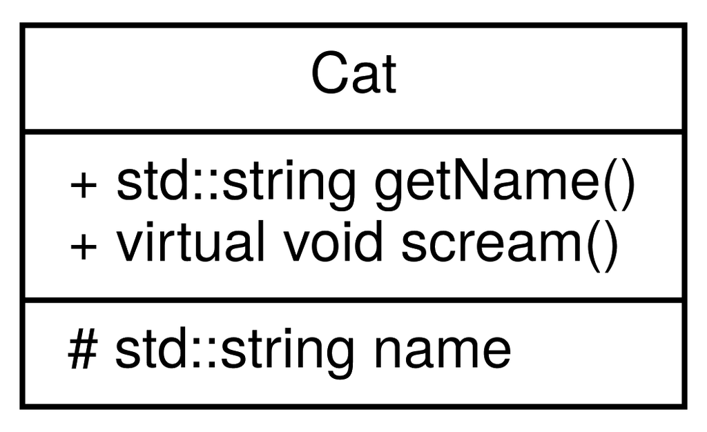

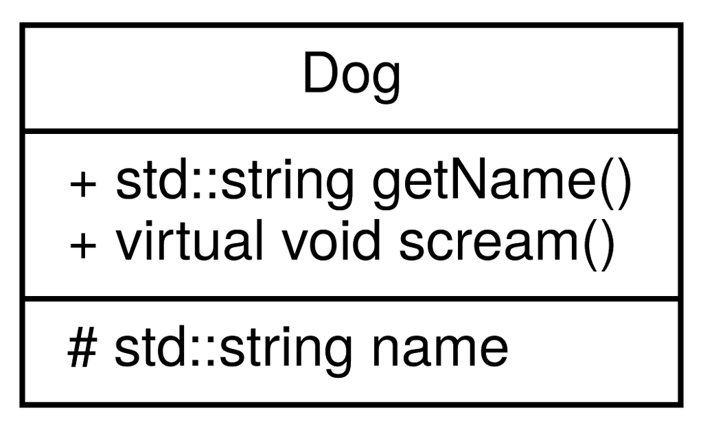

- **getName** is an accessor (why is it necessary ?) appearing twice
- Cat's **scream** is different from Dog's **scream**

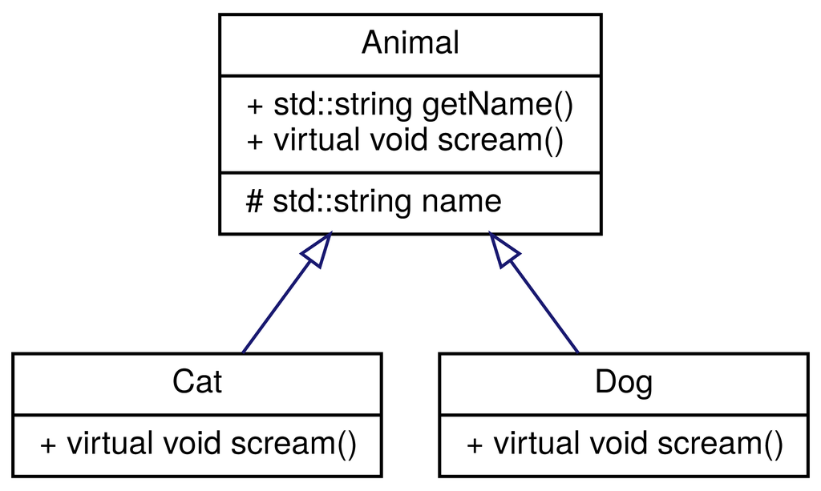

## Python inheritance syntax

```
class Dog(Animal):

    # the constructor needs to call the parent one
    def __init__ (self, **kwargs):
       Animal.__init__(self, **kwargs)

    def __del__(self):
       Animal.__del__(self)

    def scream(self):
        print('OUAFF')
```

- **scream** is simply overwritten (dictionary fashion) $\Rightarrow$ **[Overloading](https://en.wikipedia.org/wiki/Function_overloading)/[Polymorphism](https://en.wikipedia.org/wiki/Polymorphism_%28computer_science%29)**

## Python inheritance syntax

```
class Dog(Animal):

    # the constructor needs to call the parent one
    def __init__ (self, *args, **kwargs):
       super().__init__(*args, **kwargs)

    def __del__(self):
       super().__del__()

    def scream(self):
        print('OUAFF')
```

- [super()](https://docs.python.org/3/library/functions.html#super) calls in a generic way to the mother class

## [Abstract Class](https://en.wikipedia.org/wiki/Abstract_type)

- Incomplete *Class* (for some methods), cannot be instanciated
- Possible implementation:

```
class Animal(object):

    def __init__(self, name):
        self.name = name

    def scream(self):
        raise Exception('virtual function')
```

- Good practice to inherit from **Object**

## Why is it useful ?

## [Abstract Class](https://en.wikipedia.org/wiki/Abstract_type)

- A more Pythonic way using module [ABC](https://docs.python.org/3/library/abc.html)

```
from abc import ABC, abstractmethod

class Animal(ABC):

    def __init__(self, name):
        self.name = name
        super().__init__()

    @abstractmethod
    def scream(self):
        pass
```

- Cannot instanciate a class animal

```
ani = Animal('Toto')
```

```
---------------------------------------------------------------------------
TypeError                                 Traceback (most recent call last)
<ipython-input-22-3da93493cca1> in <module>
----> 1 ani = Animal("Toto")

TypeError: Can't instantiate abstract class Animal with abstract methods scream
```

## Special function: **str**

- Tweaking the behavior of print

```
class Cat:

    # ....

    def __str__(self):
      return ("Hello, this is "
              + str(self.name))
```

```
# instanciation of object
obj = Cat('kitty')
# printing it
print(obj)
```

Should execute as

```
Hello, this is kitty
```

## **item getter/setter** & [python operators](https://docs.python.org/3.5/library/operator.html)

```
class MyClass:

  def __init__(self):
    self.mylist = [ 1, 2, 3, 4]
  def __getitem__(self, index):
    return self.mylist[index]
  def __setitem__(self, index, value):
    self.mylist[index] = value
  def __delitem__(self, index):
    del self.mylist[index]
```

- Try it !

```
obj = MyClass()
print(obj[2])
```

```
obj[3] = 4
del obj[0]
```

### Important note on coding convention

- one file per (family) class
- one (family) class per file

# THANKS

## Exceptions: Dealing with errors

```
vec = np.array([1,2,3,4])
print(vec[18])
```

Program will stop and **raise** an exception

```
---------------------------------------------------------------------------
IndexError                                Traceback (most recent call last)
<ipython-input-29-9f8741cf621d> in <module>
      1 import numpy as np
      2 vec = np.array([1,2,3,4])
----> 3 print(vec[18])

IndexError: index 18 is out of bounds for axis 0 with size 4
```

## Exceptions

- Can catch an exception

```
try:
  vec = np.array([1,2,3,4])
  print(vec[18])
except IndexError as err:
  print(err)
```

```
index 18 is out of bounds for axis 0 with size 4
```

## Exceptions

- Making and raising your own exceptions

```
class MyError(RuntimeError):
  def __init__(self, value):
    self.parameter = value
  def __str__(self):
    return repr(self.parameter)
```

```
try:
  raise MyError(['important info', 1234])
except MyError as e:
  print(e)
```

```
['important info', 1234]
```

## Interactive session on making first class family

- **Series** class with the correct interface
- **Dumper** class taking a "serie as input"

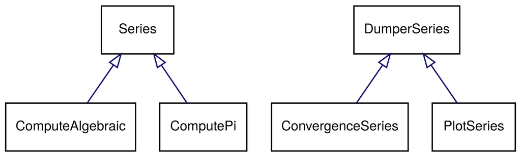